# Part I - Ford GoBike System Data Exploration

## by Diego Fernando Pinzón López

## Introduction

> This document explores a dataset which includes information about individual rides made in a bike-sharing system covering the greater San Francisco Bay area.

## Preliminary Wrangling

|  | duration_sec | start_time | end_time | start_station_id | start_station_name | start_station_latitude | start_station_longitude | end_station_id | end_station_name | end_station_latitude | end_station_longitude | bike_id | user_type | member_birth_year | member_gender | bike_share_for_all_trip |
| --- | --- | --- | --- | --- | --- | --- | --- | --- | --- | --- | --- | --- | --- | --- | --- | --- |
| 0 | 52185 | 2019-02-28 17:32:10.1450 | 2019-03-01 08:01:55.9750 | 21.0 | Montgomery St BART Station (Market St at 2nd St) | 37.789625 | -122.400811 | 13.0 | Commercial St at Montgomery St | 37.794231 | -122.402923 | 4902 | Customer | 1984.0 | Male | No |
| 1 | 42521 | 2019-02-28 18:53:21.7890 | 2019-03-01 06:42:03.0560 | 23.0 | The Embarcadero at Steuart St | 37.791464 | -122.391034 | 81.0 | Berry St at 4th St | 37.775880 | -122.393170 | 2535 | Customer | NaN | NaN | No |
| 2 | 61854 | 2019-02-28 12:13:13.2180 | 2019-03-01 05:24:08.1460 | 86.0 | Market St at Dolores St | 37.769305 | -122.426826 | 3.0 | Powell St BART Station (Market St at 4th St) | 37.786375 | -122.404904 | 5905 | Customer | 1972.0 | Male | No |
| 3 | 36490 | 2019-02-28 17:54:26.0100 | 2019-03-01 04:02:36.8420 | 375.0 | Grove St at Masonic Ave | 37.774836 | -122.446546 | 70.0 | Central Ave at Fell St | 37.773311 | -122.444293 | 6638 | Subscriber | 1989.0 | Other | No |
| 4 | 1585 | 2019-02-28 23:54:18.5490 | 2019-03-01 00:20:44.0740 | 7.0 | Frank H Ogawa Plaza | 37.804562 | -122.271738 | 222.0 | 10th Ave at E 15th St | 37.792714 | -122.248780 | 4898 | Subscriber | 1974.0 | Male | Yes |

```
(183412, 16)
duration_sec                 int64
start_time                  object
end_time                    object
start_station_id           float64
start_station_name          object
start_station_latitude     float64
start_station_longitude    float64
end_station_id             float64
end_station_name            object
end_station_latitude       float64
end_station_longitude      float64
bike_id                      int64
user_type                   object
member_birth_year          float64
member_gender               object
bike_share_for_all_trip     object
dtype: object
```

```
<class 'pandas.core.frame.DataFrame'>
RangeIndex: 183412 entries, 0 to 183411
Data columns (total 16 columns):
 #   Column                   Non-Null Count   Dtype
---  ------                   --------------   -----
 0   duration_sec             183412 non-null  int64
 1   start_time               183412 non-null  object
 2   end_time                 183412 non-null  object
 3   start_station_id         183215 non-null  float64
 4   start_station_name       183215 non-null  object
 5   start_station_latitude   183412 non-null  float64
 6   start_station_longitude  183412 non-null  float64
 7   end_station_id           183215 non-null  float64
 8   end_station_name         183215 non-null  object
 9   end_station_latitude     183412 non-null  float64
 10  end_station_longitude    183412 non-null  float64
 11  bike_id                  183412 non-null  int64
 12  user_type                183412 non-null  object
 13  member_birth_year        175147 non-null  float64
 14  member_gender            175147 non-null  object
 15  bike_share_for_all_trip  183412 non-null  object
dtypes: float64(7), int64(2), object(7)
memory usage: 22.4+ MB
```

### What is the structure of your dataset?

This data set includes information about individual rides made in a bike-sharing system covering the greater San Francisco Bay area. Comprising a meticulously cleaned collection of 174,952 records, this dataset is structured across 16 distinct fields. The data unfolds in a coherent and meaningful manner:

**Temporal Data:**

- Duration in seconds of the trip (duration_sec, integer type)
- Start time of the trip (start_time, in date format)
- End time of the trip (end_time, in date format).

**Bike Stations:**

- Identification and names of both the starting stations (start_station_id and start_station_name) and the ending stations (end_station_id and end_station_name) of the trips.
- Geographical coordinates of latitude and longitude for the starting stations (start_station_latitude and start_station_longitude) and ending stations (end_station_latitude and end_station_longitude).
- Unique identification for each bicycle (bike_id).

**User Data:**

- User type: Indicates whether the user is a "Customer" or a "Subscriber".
- User's birth year (member_birth_year).
- User's gender (member_gender).

**Additional Information:**

- Indicator of whether the trip is covered by the "bike_share_for_all_trip" program, with options "NO" and "Yes".

This description offers a structured and fluent overview of the dataset's composition and significance, highlighting the relevance of each field and its utility in analyzing shared bicycle trips in the San Francisco Bay Area.

### What is/are the main feature(s) of interest in your dataset?

This exercise is purely descriptive in nature, with our main focus being to comprehend behavioral patterns of bike trips in San Francisco. Additionally, we aim to uncover whether there are distinct patterns in trips depending on the days of the week, hours of the day, and to ascertain if there is differentiated behavior between the two user types: customers and subscribers. Some questions can help to identify the patterns in trips like these:

- When are most trips taken in terms of time of day, day of the week, or month of the year?
- How long does the average trip take?
- Do the above questions vary depending on the characteristics of the users?

### What features in the dataset do you think will help support your investigation into your feature(s) of interest?

Throughout this exercise, descriptive analyses will be conducted on the majority of variables within the dataset. However, our primary emphasis will be on three crucial variables: trip start, end times and duration (**start_time**, **end_time** and **duration_sec**, respectively). These variables hold paramount importance in identifying patterns in bike trip behaviors, as they allow us to derive relevant insights about the most frequently used days of the week, peak hours, and average travel durations for bike users.

It's noteworthy that we will be conducting segmented analyses based on user gender (**membem_gender**), user type (**user_type**), and birth year (**member_birth_year**). This approach will allow us to focus on identifying patterns of bike trip behavior and highlighting any significant trends or variations within these groups.

## Univariate Exploration

Le'ts wrangling the information

### How is the daily behavior of bicycle trips and the average duration per trip?

Firstly, we initiate the process by generating a time series graph to comprehend the time range we are dealing with and to discern patterns based on the day of the month.

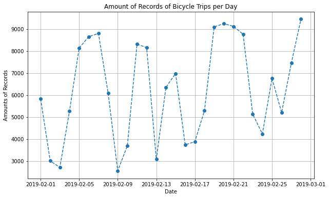

Next, we will calculate the average duration of bicycle trips. First, we create variables duration_min and duration_hour with the information duration minutes and duration hours respectively.

```
The average of a trip is: 11.73
```

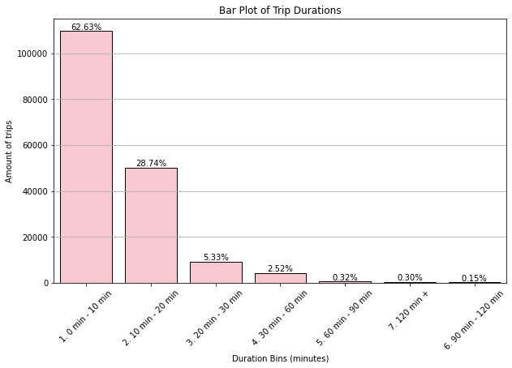

**observation:** Regarding the duration of these trips, 62% of the data indicates that a trip lasts less than 10 minutes. Additionally, 28.74% of trips have a duration between 10 and 20 minutes, meaning that in general, 90% of trips are completed in less than 20 minutes.

```
The average of a trip is: 11.73
```

Let's make a box plot with duration times (in minutes) without outliers (we consider only trips' information with less than 30 minutes).

```
Average of trip durations in bikes: 11.73
```

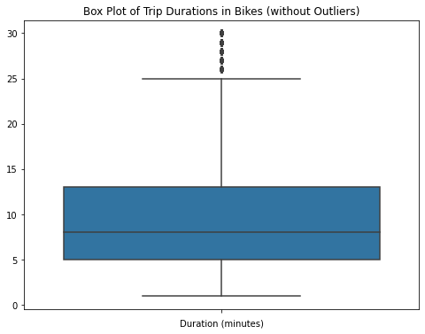

**observation:** Considering travel information lasting less than 30 minutes, a significant concentration between 5 to 13 minutes can be observed.

### How many trips are in every day of the week and every hour if the day?

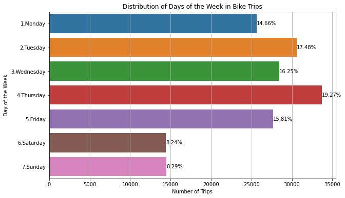

**observation:** we can see that most trips are on weekdays, with Thursday being the day with the most trips during the week. In addition, we see that generally on weekends the trips are reduced by half.

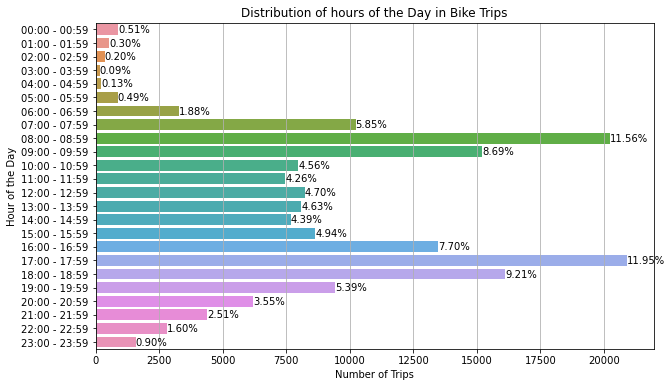

**observation:** A significant portion of bicycle journeys throughout the day occur primarily during the time slots of 7 to 9 in the morning and 4 to 7 in the evening. These two time periods represent the main usage peaks: the first one before 9 in the morning, and the second one after 5 in the afternoon.

We are going to try to see if there is an favorite station to start or to end every trip.

### Is there any interesting pattern with the start and the end stations?

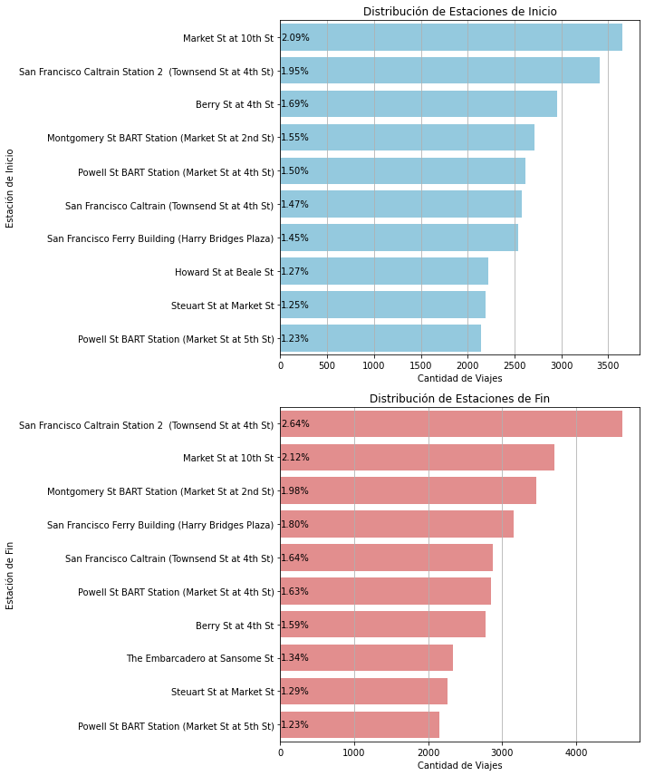

**observation:** We see some popular stations because they appear at the most popular stations to start and end the trip; however, none of the stations have more than a 3% share of the trips.

### How are the characteristics of the users?

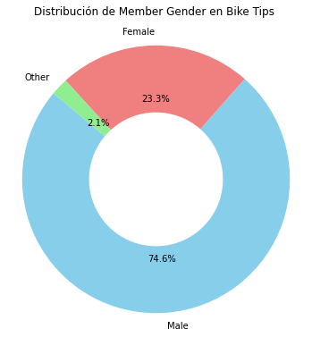

**observation:** The proportion of member users, where we obtain that 74,6% of the users are male.

Now, let's look at the proportion of user types where we can see that Subscriber has the most engagement.

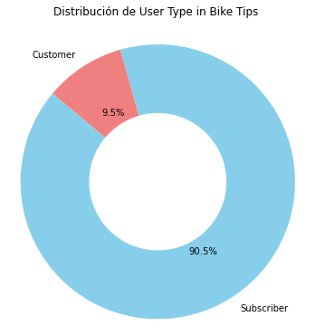

**observation:** The proportion of member users, where we obtain that 90,5% of the users are suscriber.

Now, let's explore the distribution of users by age. We'll start by calculating the age using both the birth year and the year of the records (2019).

```
count    174952.000000
mean         34.196865
std          10.118731
min          18.000000
25%          27.000000
50%          32.000000
75%          39.000000
max         141.000000
Name: age, dtype: float64
Average of age users: 34.0
```

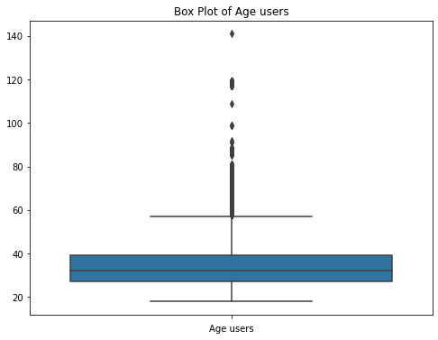

### Discuss the distribution(s) of your variable(s) of interest. Were there any unusual points? Did you need to perform any transformations?

In accordance with the analysis conducted earlier, I emphasize some of the most relevant findings.

### Of the features you investigated, were there any unusual distributions? Did you perform any operations on the data to tidy, adjust, or change the form of the data? If so, why did you do this?

Regarding the features I investigated, one that I focused on extensively was related to the start_time and end_time variables (the date and time of trip start and end). From there, I derived crucial variables such as the precise time of day and the specific day of the week. Additionally, I deemed it beneficial to convert the trip duration variable from seconds to minutes for a more insightful graphical analysis. Finally, another variable where I performed significant manipulation was the birth year, in order to estimate the approximate age of all users and conduct an age-related analysis.

## Bivariate Exploration

### How is the relation betweenn user type or gender with the duration of bike use?

Let's start by creating a box plot to observe differences between user types and trip duration (in minutes).

```
Mean of duration per type of user (in minutes):
user_type
Customer      21.844259
Subscriber    10.675685
Name: duration_min, dtype: float64
```

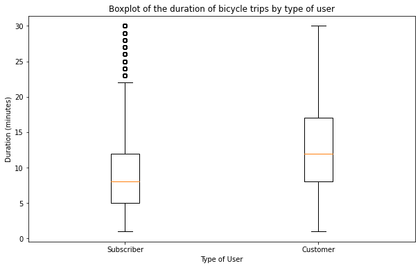

**observation:** In general, subscribers have lower usage times than Customers.

Now, let's make the same previous exercise to observe differences between gender and trip duration (in minutes).

```
Average duration by user gender (in minutes) for users who spend less than 30 minutes on the trip:
member_gender
Female    10.352060
Male       9.291263
Other     10.053326
Name: duration_min, dtype: float64
```

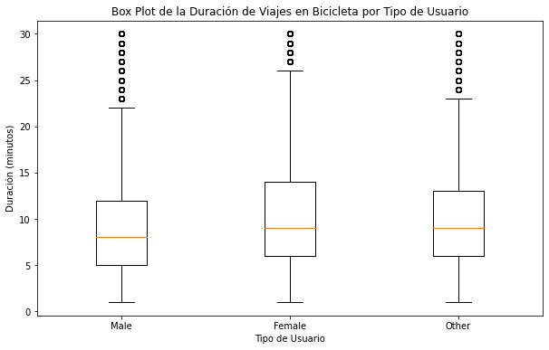

A violin Diagram can help to understand better the distribution of the duration in terms of gender.

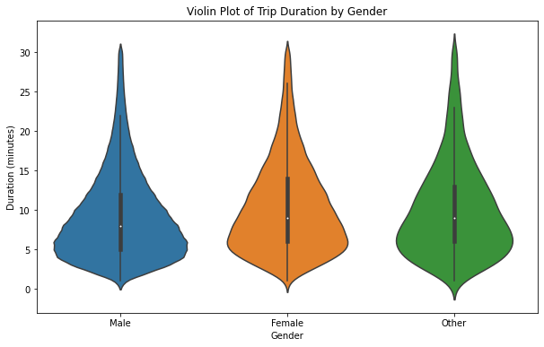

**observation:** Men have better average performance or shorter bicycle use times than women and gender Others.

### What day and time of the week has the highest participation in the use of bicycles?

To do a better understanding in times of start travel, let's make a diagram to see the days and the hours with most frecency in travels.

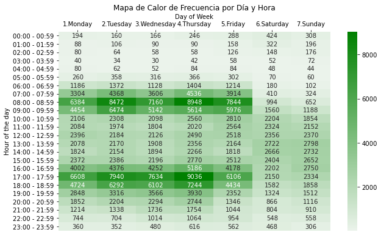

**observation:** An intriguing relationship is observed between the days and hours of trips, with a substantial engagement in bicycle usage on weekdays, both during morning and afternoon hours.

### Does age affect the loan times of bicycles?

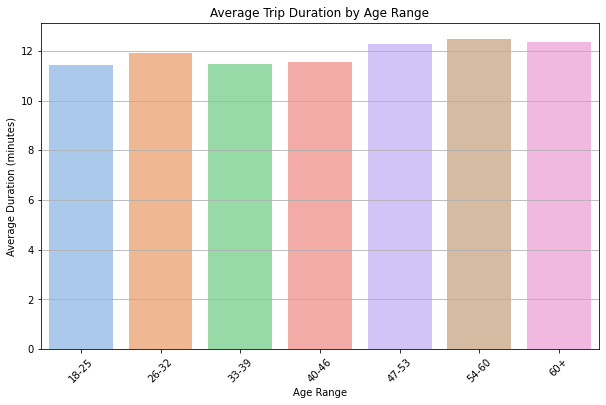

**observation:** Analyzing the average duration by age, we can see that the population between 18 and 45 years of age have a shorter duration in the use of bicycles than those over 46 years of age.

### Can we obtain valious information about latitude and longitude data?

Let's create a plot illustrating the latitude and longitude of the starting stations to gain insight into the spatial distribution of these stations across the city.

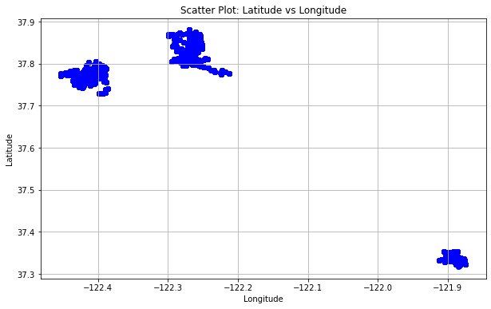

For a deeper understanding, I present an imported image below that displays the map of the stations

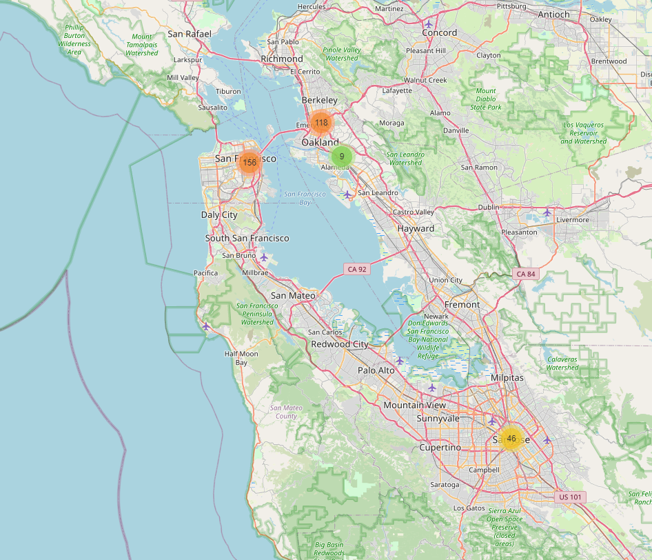

**observation:** is interesting to see how the latitude and longitude plots can be used to understand the concentration of different bike rental stations. However, for the questions we have this information will not be relevant to this analysis.

### Did you observe any interesting relationships between the other features (not the main feature(s) of interest)?

- An intriguing relationship is observed between the days and hours of trips, with a substantial engagement in bicycle usage on weekdays, both during morning and afternoon hours.
- As for the latitude and longitude data, that is, it allowed me to see that there are three main areas in which the San Francisco stations are concentrated.

## Multivariate Exploration

#### How is the relationship of the average duration time with combined variables such as gender-age, gender-type of user, age-type of user or day of week - hour of day?

Let's see if there a relation among user age, user member, and mean of the duration of bike

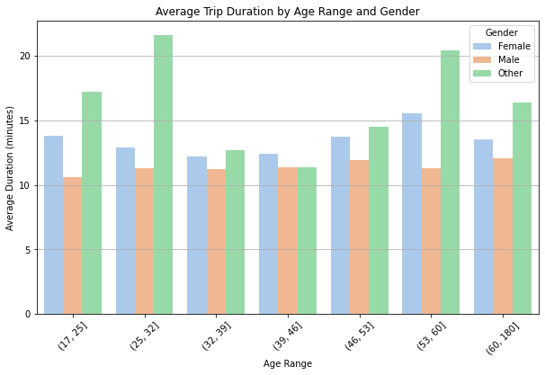

Let's see if there a relation among user age, user type, and mean of the duration of bike

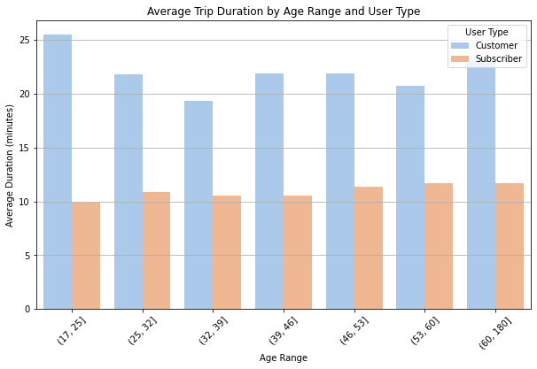

**observation:** Regardless of age, subscribers have almost half the time on the bike as customers.

Now, let's see if there a relation among type of user, user gender, and mean of the duration of bike

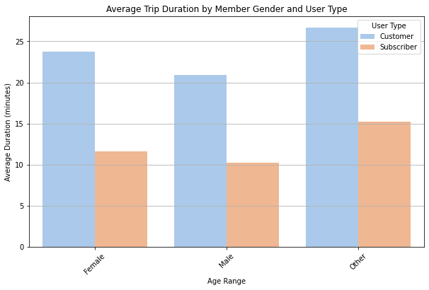

**observation:** Regardless of gender, subscribers have shorter cycling times than customers.

Now, let's see if there a relation among hour of the day, day of the week, and mean of the duration of bike

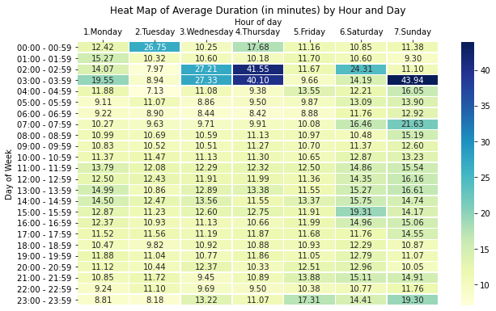

**observation:** The morning and afternoon hours, where bicycle usage is more prevalent, record shorter usage times. Conversely, the off-peak hours, occurring between 2 and 4 in the morning, are precisely when the longest average usage times are observed."

## Conclusions

- One of the key findings underscores the pattern of bicycle usage during weekdays and the morning and afternoon hours. This behavior can be attributed to the fact that residents of San Francisco utilize bicycles for commuting to work or returning home.
- In a broader sense, it is evident that men require less time for bicycle usage and constitute a larger share in the bicycle user market.
- A user categorized as 'customer' spends twice as much time on bicycle usage compared to a user marked as a 'subscriber', regardless of their age or gender. This may imply that subscribed customers utilize bicycles more frequently than customers."